# Lab 2: Exploring Rodents with ggplot2

# Data Context

The Portal Project is a long-term ecological study being conducted near Portal, AZ. Since 1977, the site has been used to study the interactions among rodents, ants and plants and their respective responses to climate. To study the interactions among organisms, we experimentally manipulate access to 24 study plots. This study has produced over 100 scientific papers and is one of the longest running ecological studies in the U.S.

We will be investigating the animal species diversity and weights found within plots at the Portal study site. The dataset is stored as a comma separated value (CSV) file. Each row holds information for a single animal, and the columns represent:

[output not shown]

# Reading the Data into R

We have seen in the practice activity that when importing a data frame, the columns that contain characters (i.e., text) are coerced (=converted) into the `factor` data type. We had to set **`stringsAsFactors`** to **`FALSE`** to avoid this hidden argument to convert our data type.

For this lab we will use the **`readr`** package (from the `tidyverse`) to read in the data and avoid having to set **`stringsAsFactors`** to **`FALSE`**

We’ll read in our data using the `read_csv()` function instead of the `read.csv()` function.

**1. Using the `read_csv()` function and the **here** package, to write the code necessary to load in the `surveys.csv` dataset.**

```r
## NOTE: This path is unique to MY project and your path may look different!
## The important part is that you use the here() function to specify your path

surveys <- read_csv(here("2_ggplot_import", "Lab", "surveys.csv"))
```

**2. What are the dimensions of these data?**

There are 30,463 rows (observations) and 15 columns (variables) in the dataset.

```r
dim(surveys)
```

```
## [1] 30463    15
```

**3. What types of variables are included in the dataset?**

```r
glimpse(surveys)
```

```
## Rows: 30,463
## Columns: 15
## $ record_id       <dbl> 63, 64, 65, 66, 67, 68, 69, 71, 74, 75, 78, 79, 81, 82…
## $ month           <dbl> 8, 8, 8, 8, 8, 8, 8, 8, 8, 8, 8, 8, 8, 8, 8, 8, 8, 8, …
## $ day             <dbl> 19, 19, 19, 19, 19, 19, 19, 19, 19, 19, 19, 19, 19, 19…
## $ year            <dbl> 1977, 1977, 1977, 1977, 1977, 1977, 1977, 1977, 1977, …
## $ plot_id         <dbl> 3, 7, 4, 4, 7, 8, 2, 7, 8, 8, 1, 7, 4, 4, 6, 19, 23, 1…
## $ species_id      <chr> "DM", "DM", "DM", "DM", "DM", "DO", "PF", "DM", "PF", …
## $ sex             <chr> "M", "M", "F", "F", "M", "F", "M", "F", "M", "F", "M",…
## $ hindfoot_length <dbl> 35, 37, 34, 35, 35, 32, 15, 36, 12, 32, 16, 34, 14, 35…
## $ weight          <dbl> 40, 48, 29, 46, 36, 52, 8, 35, 7, 22, 9, 42, 8, 41, 37…
## $ date            <date> 1977-08-19, 1977-08-19, 1977-08-19, 1977-08-19, 1977-…
## $ day_of_week     <chr> "Fri", "Fri", "Fri", "Fri", "Fri", "Fri", "Fri", "Fri"…
## $ plot_type       <chr> "Long-term Krat Exclosure", "Rodent Exclosure", "Contr…
## $ genus           <chr> "Dipodomys", "Dipodomys", "Dipodomys", "Dipodomys", "D…
## $ species         <chr> "merriami", "merriami", "merriami", "merriami", "merri…
## $ taxa            <chr> "Rodent", "Rodent", "Rodent", "Rodent", "Rodent", "Rod…
```

## Plotting with **`ggplot2`**

`ggplot()` graphics are built step by step by adding new elements. Adding layers in this fashion allows for extensive flexibility and customization of plots.

To build a `ggplot()`, we will use the following basic template that can be used for different types of plots:

`ggplot(data = <DATA>, mapping = aes(<VARIABLE MAPPINGS>)) + <GEOM_FUNCTION>()`

Let’s get started!

## Scatterplot

**4. First, let’s create a scatterplot of the relationship between `weight` (on the x-axis) and `hindfoot_length` (on the y-axis).**

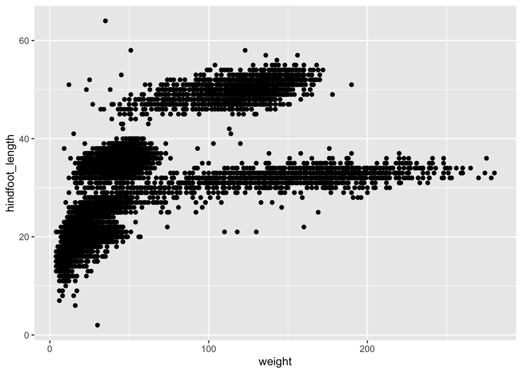

```r
ggplot(data = surveys,
       mapping = aes(x = weight, y = hindfoot_length)) +
    geom_point()
```

We can see there are **a lot** of points plotted on top of each other. Let’s try and modify this plot to extract more information from it.

**5. Let’s add transparency (`alpha`) to the points, to make the points more transparent and (possibly) easier to see.**

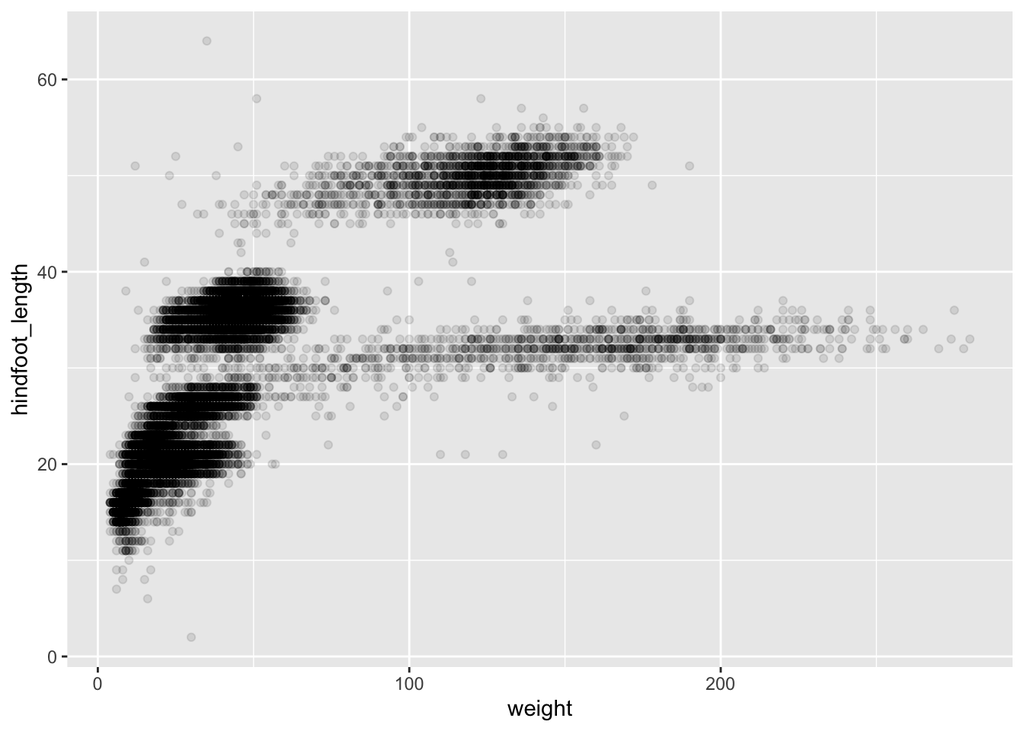

```r
ggplot(data = surveys,
       mapping = aes(x = weight, y = hindfoot_length)) +
    geom_point(alpha = 0.1)
```

```r
## alpha reduces the opacity of the points
## 0 is fully transparent
## 1 is the original opacity
```

Well, that is better, but there are still large clumps of data being plotted on top of each other. Let’s try another tool!

**6. Add some jitter to the points in the scatterplot, using `geom_jitter()`.**

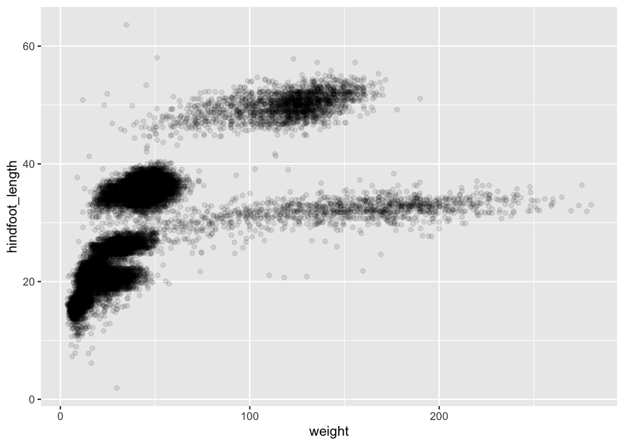

```r
ggplot(data = surveys,
       mapping = aes(x = weight, y = hindfoot_length)) +
    geom_jitter(alpha = 0.1)
```

## Faceting

Despite our best efforts there is still a substantial amount of overplotting occurring in our scatterplot. Let’s try splitting the dataset into smaller subsets and see if that allows for us to see the trends a bit better.

**7. Facet your jittered scatterplot by `species_id`.**

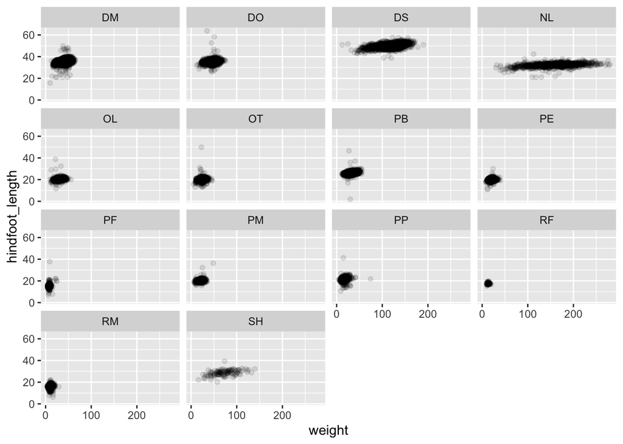

```r
ggplot(data = surveys,
       mapping = aes(x = weight, y = hindfoot_length)) +
    geom_jitter(alpha = 0.1) +
  facet_wrap(~ species_id)
```

# Boxplots & Density Ridges

**8. Create side-by-side boxplots to visualize the distribution of weight within each species.**

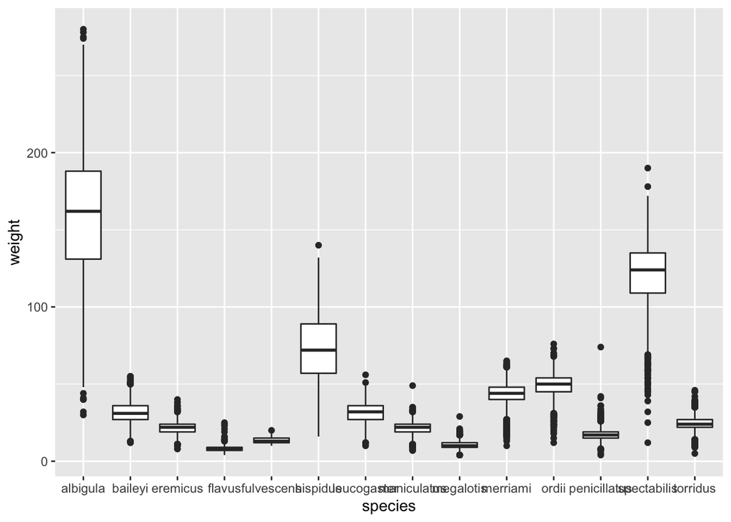

```r
ggplot(data = surveys,
       mapping = aes(x = species, y = weight)) +
    geom_boxplot()
```

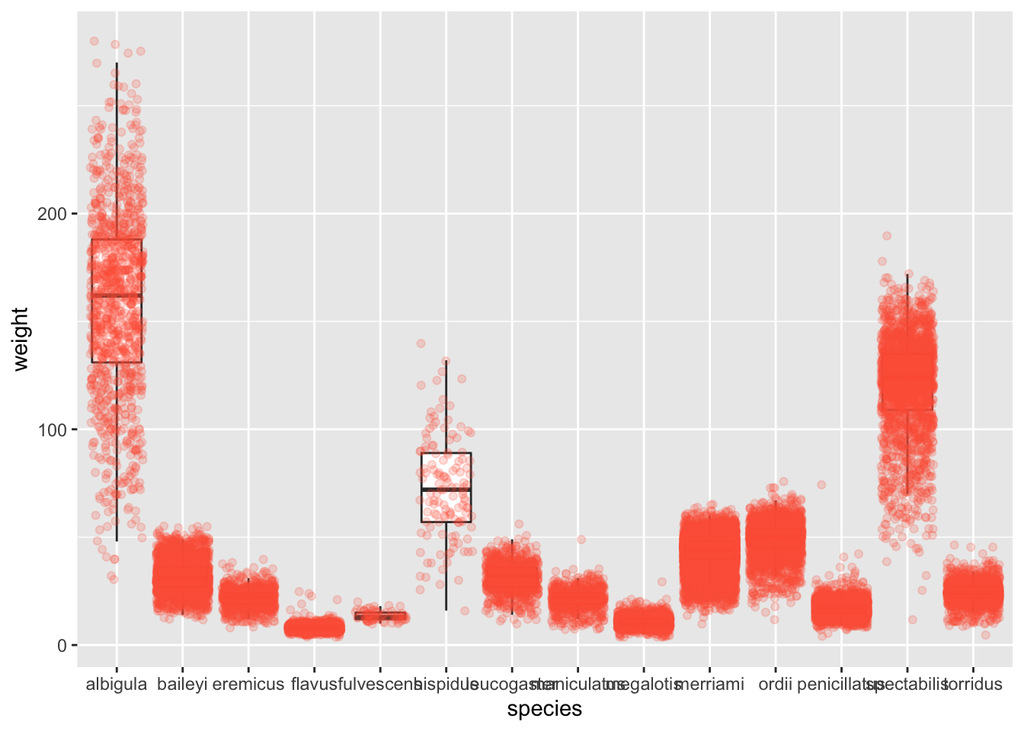

```r
surveys %>%
  ggplot(mapping = aes(x = species, y = weight)) +
    geom_boxplot(outlier.shape = NA) +
    geom_jitter(alpha = 0.2, color = "tomato")
```

**9. Inspect the help file for `geom_boxplot()` and see how you can remove the outliers from being plotted by `geom_boxplot()`. Make this change in the code above!**